# 04 Smoking 2

# (04) Comparison of Samples with *Student*’s $t$ test

## Preamble

```r
# Preamble

## Install Pacman
load.pac <- function() {

  if(require("pacman")){
    library(pacman)
  }else{
    install.packages("pacman")
    library(pacman)
  }

  pacman::p_load(xts, sp, gstat, ggplot2, rmarkdown, reshape2, ggmap,
                 parallel, dplyr, plotly, tidyverse, reticulate, UsingR, Rmpfr,
                 swirl, corrplot, gridExtra, mise, latex2exp, tree, rpart, lattice,
                 coin)


   mise()
}

load.pac()
```

```r
load(file = "~/Notes/DataSci/ThinkingAboutData/TAD.rdata")
load(file = "./TAD.rdata")
```

```r
knitr::opts_chunk$set(
  fig.path = "./figure/"
)
```

## Permutation Test

So in wk 3 the code to test for a difference was to the effect of:

```r
# Aggregate is a wrapper for apply
  ## As a Function
aggregate(bwt ~ smoke, birthwt, mean)
```

| smoke | bwt |
| --- | --- |
| no | 3515.639 |
| yes | 3260.285 |

```r
  ## For Data Frames
aggregate(x = birthwt$bwt, by = list(smoking_status = birthwt$smoke), FUN = mean)
```

| smoking_status | x |
| --- | --- |
| no | 3515.639 |
| yes | 3260.285 |

```r
obs_diff <- aggregate(x = birthwt$bwt, by = list(smoking_status = birthwt$smoke), FUN = mean)[,2] %>% diff()



sim_diff_samples <- replicate(1000, {
  smoke.sim <- birthwt
  smoke.sim$smoke <- sample(birthwt$smoke)
  sim_diff <-
    aggregate(bwt ~ smoke, smoke.sim, mean)[, 2] %>% diff()
})

# H_a, bwt less in smoking

(pval <- sim_diff_samples < obs_diff) %>% mean()
```

```
[1] 0
```

## Wilcoxon-Mann-Whitney Test

Suppose that we wanted to use the $U$-Statistic from the *Wilcoxon-Mann-Whitney* test:

> *U* is the number of data points where $s_i$ < $n_i$;

### The outer Product again

In order to perform this test we can use the outer product (as opposed to an awful nested for loop), for more information on the use of the outer product refer to:

- Using the Outer Product for Wilcoxon-Mann-Whitney Test
- The Outer Product Generally

```r
# Return all the birthweights for nonSmokers
## method 1
bwt_nonsmoke <- birthwt[birthwt$smoke=="no",]$bwt
bwt_smoke <- birthwt[birthwt$smoke=="yes",]$bwt
## method 2
bwt_nonsmoke <- subset(x = birthwt, subset = birthwt$smoke=="no", select = bwt, drop = TRUE)
bwt_smoke <- subset(x = birthwt, subset = birthwt$smoke=="yes", select = bwt, drop = TRUE)

# Sum the values
outer(bwt_smoke, bwt_nonsmoke, "<") %>% sum()
```

```
[1] 229164
```

This can be done by using the built-in functionj (any differences will be due to special treatment when observations are equal):

```r
wilcox.test(bwt ~ smoke, birthwt, alternative = "greater")
```

```
    Wilcoxon rank sum test with continuity correction

data:  bwt by smoke
W = 231918, p-value < 2.2e-16
alternative hypothesis: true location shift is greater than 0
```

## Standardisation

**#standardise**

It is often useful to standardise data, an example of this is when performing PCA, in *R* it is also known as scaling the data.

### Standardise the Observations

```r
birthwt$std_bwt <-  scale(birthwt$bwt, center = TRUE, scale = TRUE)

xbar <- mean(birthwt$std_bwt)
s    <- sd(birthwt$std_bwt)
x    <- birthwt$std_bwt
birthwt$std_bwt <- (x-xbar)/s
```

#### Calculate the Pooled Variance

$$\begin{aligned}
s_{p}^2 &= \frac{1}{n_1 - 1 + n_2 - 1} \cdot \sum^{n_1+ n_2}_{i= 1} \left[ \left( x_i- \overline{x} \right)^2 \right] \\
\ \\
&= \frac{(n_1 - 1) \times s^2_1 + (n_2 - 1) \times s^2_2}{n_1- 1 + n_2- 1}
\end{aligned}$$

```r
# Simple
(v_p1 <- var(birthwt$bwt))
```

```
[1] 270498.5
```

```r
s_p1 <- sd(birthwt$bwt)

# Formula
## Summary Stats
### Smokers
n_s <- sum(birthwt$smoke=="yes")
df_s <- n_s -1
sd_s <- sd(birthwt$bwt[birthwt$smoke=="yes"])
xbar_s <- mean(birthwt$bwt[birthwt$smoke=="yes"])
var_s <- var(birthwt$bwt[birthwt$smoke=="yes"])
### Non Smokers
n_n <- sum(birthwt$smoke=="no")
df_n <- n_n -1
xbar_n <- mean(birthwt$bwt[birthwt$smoke=="no"])
sd_n <- sd(birthwt$bwt[birthwt$smoke=="no"])
var_n <- var(birthwt$bwt[birthwt$smoke=="no"])

(v_p2 <- (df_s * sd_s^2 + df_n * sd_n^2)/(df_s + df_n))
```

```
[1] 255114.6
```

```r
s_p2 <- sqrt(v_p2)
```

### Calculate the standard error for the difference

For proofs refer to the [org file](https://ryangreenup.github.io/Org-Publish/ThinkingAboutData.html#org0ac88e7).

$$\begin{aligned}
\sigma_{\overline{x}_{1}\pm \overline{x}_{2}} &=\sigma_p \cdot \sqrt{\frac{1}{n_{1}} + \frac{1}{n_{2}}}\\
\end{aligned}$$

```r
SED <- s_p1* sqrt(1/n_s + 1/n_n)
SED <- s_p2* sqrt(1/n_s + 1/n_n)
```

### Calculate the t-statistic

```r
#    bwt ~ smoke
(t_stat <- (xbar_n - xbar_s)/(SED))
```

```
[1] 8.652745
```

#### Using the Built in t.test

```r
t.test(bwt ~ smoke, birthwt)
```

```
    Welch Two Sample t-test

data:  bwt by smoke
t = 8.5811, df = 1003.2, p-value < 2.2e-16
alternative hypothesis: true difference in means is not equal to 0
95 percent confidence interval:
 196.9596 313.7478
sample estimates:
 mean in group no mean in group yes
         3515.639          3260.285
```

### Permutation Again

In order to perform the permutation based test we can use an additional library:

```r
library(coin)
coin::oneway_test(formula = bwt ~ smoke,
                  data = birthwt,
                  distribution = coin::approximate(nresample = 1000),
                  alternative = "greater")
```

```
    Approximative Two-Sample Fisher-Pitman Permutation Test

data:  bwt by smoke (no, yes)
Z = 8.4031, p-value < 0.001
alternative hypothesis: true mu is greater than 0
```

## Confidence Intervals

The mean value of a sample will depend on the sample taken, this is however an estimator for the population mean and so can be used to predict where the population mean truly lies. The Central Limit Theorem Provides that the distribution of Sample Means follows a normal distribution:

$$\overline{X} \sim \mathcal{N}\left( \mu, \left( \frac{\sigma}{\sqrt{n} } \right) \right)$$

### Bootstrap

Bootstrapping involves taking multiple samples from a sample (allowing reppetition also known as replacement) and then plotting the distribution of a test statistic, this represents an estimate of the population distribution and is known as resampling. Generally this is done for the variance or median of a data set because a $t$ -distribution can be used to create a confidence interval of the data set.

- The basic idea being that the number of different ways take 10 observations with repetition from a sample of 30 is very large $^{(10+30-1)}C_{10}>9E^9$ and these samples would be expected to ideally behave similarly to samples taken from the population, given such a large size, sampling statistics should represent a good prediction of the population.

#### Writing our own Function

Implementing bootstrapping simply involves resampling the data and then recording the test statistic:

```r
bwt_smoke    <- birthwt[birthwt$smoke=="yes", 1]
bwt_nonsmoke <- birthwt[birthwt$smoke=="no" , 1]
d0 <- mean(bwt_smoke) - mean(bwt_nonsmoke)


d_vec <- replicate(3000, {
 bwt_smoke <- sample(bwt_smoke, replace = TRUE)
 bwt_nonsmoke <- sample(bwt_nonsmoke, replace = TRUE)
 d <- mean(bwt_smoke) - mean(bwt_nonsmoke)
 d
})
```

#### Plot Histogram (Base)

```r
d_vec
```

[output not shown]

[output cut: 49 more lines]

#### Plot Histogram (ggplto2)

This can also be done in `ggplot2` by using the `stat_function()` with `dnorm()`:

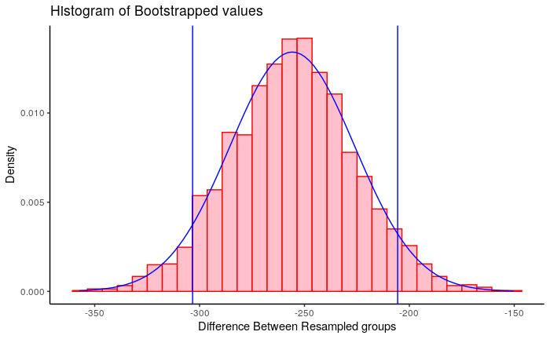

```r
d_vec.tb <- tibble::enframe(d_vec, value = "difference")
d_vec.tb <- d_vec.tb %>%  dplyr::select("difference")


ggplot(d_vec.tb, aes(x = difference)) +
  geom_histogram(aes(y = ..density..), fill = "pink", col = "red") +
  stat_function(col = "blue",
                fun = dnorm,
                args = list(mean = mean(d_vec.tb$difference),
                            sd = sd(d_vec.tb$difference))) +
  geom_vline(xintercept = quantile(d_vec.tb$difference, c(0.05)), col = "blue") +
  geom_vline(xintercept = quantile(d_vec.tb$difference, c(0.95)), col = "blue") +
  theme_classic() +
  labs(title = "Histogram of Bootstrapped values", x = "Difference Between Resampled groups", y = "Density")
```

```r
  quantile(d_vec.tb$difference, c(0.05))
```

```
       5%
-303.3204
```

**#bootstrap**

#### Using the `boot()` library

The boot library will take a data set and a function as an argument and perform resampling, however, the function passed to it must take two arguments, a dataframe and an index, boot will pass a matrix of values to that function where in each row represents a subsequent re-sample.

```r
library(boot)

# Create a Function for Mean Differences
mean_diff <- function(dataframe,i) {
    resampled_data = dataframe[i,]
    -diff(aggregate(bwt ~ smoke, resampled_data, mean)$bwt)
}

# Use the boot Function
b <- boot(birthwt, mean_diff, R = 1000, strata = birthwt$smoke)
boot.ci(b, type="basic", conf = 0.87)
```

```
BOOTSTRAP CONFIDENCE INTERVAL CALCULATIONS
Based on 1000 bootstrap replicates

CALL :
boot.ci(boot.out = b, conf = 0.87, type = "basic")

Intervals :
Level      Basic
87%   (211.1, 298.1 )
Calculations and Intervals on Original Scale
```

## t-based

Generally the $t$ -distribution can be used in order to give confidence intervals for the true population value of the mean:

```r
t.test(bwt ~ smoke, data = birthwt, var.equal = TRUE)
```

```
    Two Sample t-test

data:  bwt by smoke
t = 8.6527, df = 1224, p-value < 2.2e-16
alternative hypothesis: true difference in means is not equal to 0
95 percent confidence interval:
 197.4554 313.2520
sample estimates:
 mean in group no mean in group yes
         3515.639          3260.285
```

```r
t.test(bwt ~ smoke, data = birthwt, var.equal = TRUE, conf = 0.99)
```

```
    Two Sample t-test

data:  bwt by smoke
t = 8.6527, df = 1224, p-value < 2.2e-16
alternative hypothesis: true difference in means is not equal to 0
99 percent confidence interval:
 179.2189 331.4885
sample estimates:
 mean in group no mean in group yes
         3515.639          3260.285
```

```r
t.test(bwt ~ smoke, data = birthwt, var.equal = FALSE, conf = 0.99)
```

```
    Welch Two Sample t-test

data:  bwt by smoke
t = 8.5811, df = 1003.2, p-value < 2.2e-16
alternative hypothesis: true difference in means is not equal to 0
99 percent confidence interval:
 178.5573 332.1501
sample estimates:
 mean in group no mean in group yes
         3515.639          3260.285
```

Notice how being able to assume that the populations have the same variance can improve the prediction, this is because it reduces the standard error which is $\frac{\sigma}{\sqrt{n} }$

## Challenge

### Sales Data

Using the data `salesEW.csv`:

- determine if there is a difference in mean sales between the East and West offices.
- Compute the 90% confidence interval for the difference in means.

#### Difference in Mean Values

Presuming that the variances are equal:

```r
# Perform the t-Test
# salesEW
sales_test <- t.test(sales ~ office, data = salesEW, var.equal = TRUE, conf = 0.9)

# Is there a difference in mean sales?
if (sales_test$p.value < 0.1) {
  paste("There is a difference in average sales between offices (p=", signif(sales_test$p.value, 1), ")") %>% print()
} else {
  print("There is insufficient evidence to suggest a difference in the average sales between offices")
}
```

```
[1] "There is a difference in average sales between offices (p= 0.06 )"
```

```r
# What is a 90% confidence interval for the average difference
upr <- sales_test$conf.int[2]
lwr <- sales_test$conf.int[1]
  ## What's the direction?
  (office_means <- aggregate(sales ~ office, salesEW, mean))
```

| office | sales |
| --- | --- |
| east | 162.6991 |
| west | 154.0425 |

```r
    # East Sells More

  paste0("The Eastern Office Sells more by an interval of (", signif(lwr, 2), ", ", signif(upr, 2), ")") %>% print()
```

```
[1] "The Eastern Office Sells more by an interval of (1.2, 16)"
```

Hence it can be concluded that:

- The probability of concluding that the offices sell differing amounts under the assumption that there is no difference between the two offices is only 6% and hence this is rejected and it is accepted that the offices sell differing amounts.
  - The $p$-value for the Eastern office selling more is 2.8%.
- The probability of taking a sample from the offices and finding the average difference from West to East outside the range of an increase (1.2, 16) is only 10%
  - If the null hypothesis is that the difference is 0, the probability of incorrectly rejecting that null hypothesis is hence 10%
    - (This means assuming that the null hypothesis is true, be careful of the distinction between the *False Discovery Rate* and the *False Positive Rate*, mixing these two up is known as the *Base Rate Fallacy*)

An equivalent interpretation of the Confidence interval would be:

- If a 90% confidence interval was drawn from a sample of the difference in sales, the probability of the actual population mean value being contained in that interval would be 90%
  - i.e. if 30 samples were taken, the true population mean would be expected to be found in 27 of those intervals.
    - Or rather if $30\times10^9$ samples were taken, the true population would be found in $27\times 10^9$ rounded to 2 sig. figures.

Although the difference is statistically significant, the difference represents less than 10% of the recorded sales and so the difference would be a non-meaningful significant difference.

### Spider Data

Using the data `spider.csv`:

- determine if there is an increase in mean anxiety levels when seeing a spider.
- Compute the confidence interval for the differenc in mean anxiety levels

#### Greater Mean value

In this case we won’t assume that the variance between the groups is equal, perhaps certain individuals react differently to photographs for particular reasons and so this might cause a greater spread of the data for the photo group (i.e. this possibility substantiates an evidentiary burden, there is a persuasive burden required to take the variances as equal)

```r
## create the t.test
str(spider)
```

```
'data.frame':   24 obs. of  2 variables:
 $ Group  : Factor w/ 2 levels "Picture","Real Spider": 1 1 1 1 1 1 1 1 1 1 ...
 $ Anxiety: int  30 35 45 40 50 35 55 25 30 45 ...
```

```r
(spider_test <- t.test(formula = Anxiety ~ Group, data = spider, var.equal = FALSE, alternative = "greater"))
```

```
    Welch Two Sample t-test

data:  Anxiety by Group
t = -1.6813, df = 21.385, p-value = 0.9464
alternative hypothesis: true difference in means is greater than 0
95 percent confidence interval:
 -14.15808       Inf
sample estimates:
    mean in group Picture mean in group Real Spider
                       40                        47
```

```r
(spider_test <- t.test(formula = Anxiety ~ Group, data = spider, var.equal = FALSE, alternative = "less"))
```

```
    Welch Two Sample t-test

data:  Anxiety by Group
t = -1.6813, df = 21.385, p-value = 0.05362
alternative hypothesis: true difference in means is less than 0
95 percent confidence interval:
      -Inf 0.1580825
sample estimates:
    mean in group Picture mean in group Real Spider
                       40                        47
```

```r
(spider_test <- t.test(formula = Anxiety ~ Group, data = spider, var.equal = FALSE, alternative = "two.sided"))
```

```
    Welch Two Sample t-test

data:  Anxiety by Group
t = -1.6813, df = 21.385, p-value = 0.1072
alternative hypothesis: true difference in means is not equal to 0
95 percent confidence interval:
 -15.648641   1.648641
sample estimates:
    mean in group Picture mean in group Real Spider
                       40                        47
```

```r
spider_test$conf.int
```

```
[1] -15.648641   1.648641
attr(,"conf.level")
[1] 0.95
```

#### Confidence Interval; Alternative Greater

A 95% confidence Interval is such that if multiple samples and corresponding Intervals were generated, the true population mean would lie within the confidence interval in 0.95 of the samples.

The confidence Interval is that the values are greater than -14, this means that there is a 95% probability that the true population mean is greater than -14.

The p-value is the probability of rejecting the null hypothesis when it is true, rejecting the null hypothesis will depend on the alternative and so it stands to reason that the confidence interval will also depend on the alternative, it’s easier to show that the values are simply different than it is to show one is actually larger.

#### Confidence Interval; Alternative two-sided

```r
str(spider)
```

```
'data.frame':   24 obs. of  2 variables:
 $ Group  : Factor w/ 2 levels "Picture","Real Spider": 1 1 1 1 1 1 1 1 1 1 ...
 $ Anxiety: int  30 35 45 40 50 35 55 25 30 45 ...
```

```r
(spider_test <- t.test(Anxiety ~ Group, spider, var.equal = FALSE, alternative = "two.sided", conf=0.9))
```

```
    Welch Two Sample t-test

data:  Anxiety by Group
t = -1.6813, df = 21.385, p-value = 0.1072
alternative hypothesis: true difference in means is not equal to 0
90 percent confidence interval:
 -14.1580825   0.1580825
sample estimates:
    mean in group Picture mean in group Real Spider
                       40                        47
```

```r
paste("There is 90% probability that the average anxiety level induced by a mere Picture of a spider will be different from that of a spider by between", signif(spider_test$conf.int[1], 2), "and", signif(spider_test$conf.int[2], 2))
```

```
[1] "There is 90% probability that the average anxiety level induced by a mere Picture of a spider will be different from that of a spider by between -14 and 0.16"
```

If multiple samples from the population were taken, 90% of those drawn intervals would contain the population mean value, by such reasoning the probability of this confidence interval, (-14, 0.16), containing the true population mean is 90%.

This could be visualised by looking at the data or by bootstrapping some more

```r
# TODO generate a bootstrap of values
# Create the Bootstrap

# Create a Function for Mean Differences
mean_diff <- function(dataframe,i) {
    resampled_data = dataframe[i,]
    -diff(aggregate(Anxiety ~ Group, resampled_data, mean)$Anxiety)
}

# Use the boot Function
b <- boot(spider, mean_diff, R = 1000, strata = spider$Group)
boot.ci(b, type="basic", conf = 0.87)
```

```
BOOTSTRAP CONFIDENCE INTERVAL CALCULATIONS
Based on 1000 bootstrap replicates

CALL :
boot.ci(boot.out = b, conf = 0.87, type = "basic")

Intervals :
Level      Basic
87%   (-12.500,  -1.167 )
Calculations and Intervals on Original Scale
```

```r
(spider_test <- t.test(Anxiety ~ Group, spider, var.equal = FALSE, alternative = "two.sided", conf=0.9))
```

```
    Welch Two Sample t-test

data:  Anxiety by Group
t = -1.6813, df = 21.385, p-value = 0.1072
alternative hypothesis: true difference in means is not equal to 0
90 percent confidence interval:
 -14.1580825   0.1580825
sample estimates:
    mean in group Picture mean in group Real Spider
                       40                        47
```

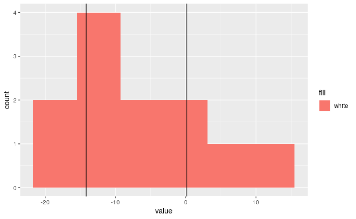

```r
library(tidyverse)


spider_real <- spider

diffs <- spider$Anxiety[spider$Group=="Picture"] -  spider$Anxiety[spider$Group=="Real Spider"]
diffs <- tibble::enframe(diffs)

ggplot(diffs, aes(x = value, fill = "white")) +
  geom_histogram(bins = 6 ) +
  geom_vline(xintercept = spider_test$conf.int[1]) +
  geom_vline(xintercept = spider_test$conf.int[2])
```